# Chapter 4 - Clustering and classification

Libraries loaded, let’s get clustering. First up we’ll look at the structure and dimensions of the Boston data, a dataframe generously provided as part of the R package MASS.If you want to know more about this dataset have a look [here](https://stat.ethz.ch/R-manual/R-devel/library/MASS/html/Boston.html). Now a quick overview of the data:

```r
str(Boston)
```

```
## 'data.frame':    506 obs. of  14 variables:
##  $ crim   : num  0.00632 0.02731 0.02729 0.03237 0.06905 ...
##  $ zn     : num  18 0 0 0 0 0 12.5 12.5 12.5 12.5 ...
##  $ indus  : num  2.31 7.07 7.07 2.18 2.18 2.18 7.87 7.87 7.87 7.87 ...
##  $ chas   : int  0 0 0 0 0 0 0 0 0 0 ...
##  $ nox    : num  0.538 0.469 0.469 0.458 0.458 0.458 0.524 0.524 0.524 0.524 ...
##  $ rm     : num  6.58 6.42 7.18 7 7.15 ...
##  $ age    : num  65.2 78.9 61.1 45.8 54.2 58.7 66.6 96.1 100 85.9 ...
##  $ dis    : num  4.09 4.97 4.97 6.06 6.06 ...
##  $ rad    : int  1 2 2 3 3 3 5 5 5 5 ...
##  $ tax    : num  296 242 242 222 222 222 311 311 311 311 ...
##  $ ptratio: num  15.3 17.8 17.8 18.7 18.7 18.7 15.2 15.2 15.2 15.2 ...
##  $ black  : num  397 397 393 395 397 ...
##  $ lstat  : num  4.98 9.14 4.03 2.94 5.33 ...
##  $ medv   : num  24 21.6 34.7 33.4 36.2 28.7 22.9 27.1 16.5 18.9 ...
```

```r
dim(Boston)
```

```
## [1] 506  14
```

```r
summary(Boston$crim)
```

```
##     Min.  1st Qu.   Median     Mean  3rd Qu.     Max.
##  0.00632  0.08204  0.25650  3.61400  3.67700 88.98000
```

```r
summary(Boston$tax)
```

```
##    Min. 1st Qu.  Median    Mean 3rd Qu.    Max.
##   187.0   279.0   330.0   408.2   666.0   711.0
```

So in brief, this data describes housing values in the suburbs of Boston. We have 14 variables and 506 observations.The variable *crim* refers to per capita crime rate and will be our primary variable of interest. Examples of other variables are *chas*, a dichotomous variable describing whether the area bounds the river Charles or not; *rm*, the average number of rooms per dwelling in the area and *ptratio*, the ratio of pupils to teacher. Check out the link above for full details on the variables.

As is obvious from the summary above, the scales of these variables are very dissimilar (I used *crim* and *tax* to illustrate this). This is not a problem as long as we’re looking at correlations, where they’re standardized anyway, but later we’ll standardize them for our other analyses.

Now for a quick look at how these variables interact:

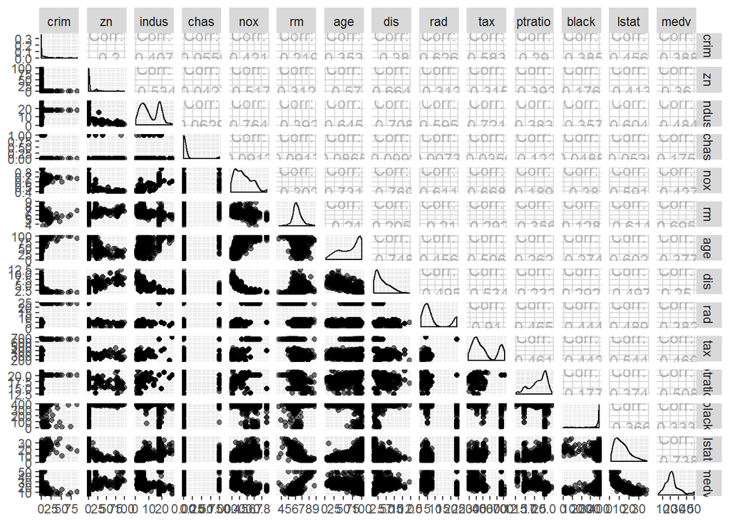

```r
p <- ggpairs(Boston, mapping = aes(alpha = 0.3), lower = list(combo = wrap("facethist", bins = 20)))
p
```

From this, we can tell that some of the variables seem to be quite strongly related and that not very many have anything close to a normal distribution. So let’s have a look at the correlation matrix to get some figures for those relationships. Below the correlation matrix I’ll do a correlation plot to illustrate these figures, because I can:

```r
cor_matrix <- cor(Boston) %>% round(digits = 2)
cor_matrix
```

```
##          crim    zn indus  chas   nox    rm   age   dis   rad   tax
## crim     1.00 -0.20  0.41 -0.06  0.42 -0.22  0.35 -0.38  0.63  0.58
## zn      -0.20  1.00 -0.53 -0.04 -0.52  0.31 -0.57  0.66 -0.31 -0.31
## indus    0.41 -0.53  1.00  0.06  0.76 -0.39  0.64 -0.71  0.60  0.72
## chas    -0.06 -0.04  0.06  1.00  0.09  0.09  0.09 -0.10 -0.01 -0.04
## nox      0.42 -0.52  0.76  0.09  1.00 -0.30  0.73 -0.77  0.61  0.67
## rm      -0.22  0.31 -0.39  0.09 -0.30  1.00 -0.24  0.21 -0.21 -0.29
## age      0.35 -0.57  0.64  0.09  0.73 -0.24  1.00 -0.75  0.46  0.51
## dis     -0.38  0.66 -0.71 -0.10 -0.77  0.21 -0.75  1.00 -0.49 -0.53
## rad      0.63 -0.31  0.60 -0.01  0.61 -0.21  0.46 -0.49  1.00  0.91
## tax      0.58 -0.31  0.72 -0.04  0.67 -0.29  0.51 -0.53  0.91  1.00
## ptratio  0.29 -0.39  0.38 -0.12  0.19 -0.36  0.26 -0.23  0.46  0.46
## black   -0.39  0.18 -0.36  0.05 -0.38  0.13 -0.27  0.29 -0.44 -0.44
## lstat    0.46 -0.41  0.60 -0.05  0.59 -0.61  0.60 -0.50  0.49  0.54
## medv    -0.39  0.36 -0.48  0.18 -0.43  0.70 -0.38  0.25 -0.38 -0.47
##         ptratio black lstat  medv
## crim       0.29 -0.39  0.46 -0.39
## zn        -0.39  0.18 -0.41  0.36
## indus      0.38 -0.36  0.60 -0.48
## chas      -0.12  0.05 -0.05  0.18
## nox        0.19 -0.38  0.59 -0.43
## rm        -0.36  0.13 -0.61  0.70
## age        0.26 -0.27  0.60 -0.38
## dis       -0.23  0.29 -0.50  0.25
## rad        0.46 -0.44  0.49 -0.38
## tax        0.46 -0.44  0.54 -0.47
## ptratio    1.00 -0.18  0.37 -0.51
## black     -0.18  1.00 -0.37  0.33
## lstat      0.37 -0.37  1.00 -0.74
## medv      -0.51  0.33 -0.74  1.00
```

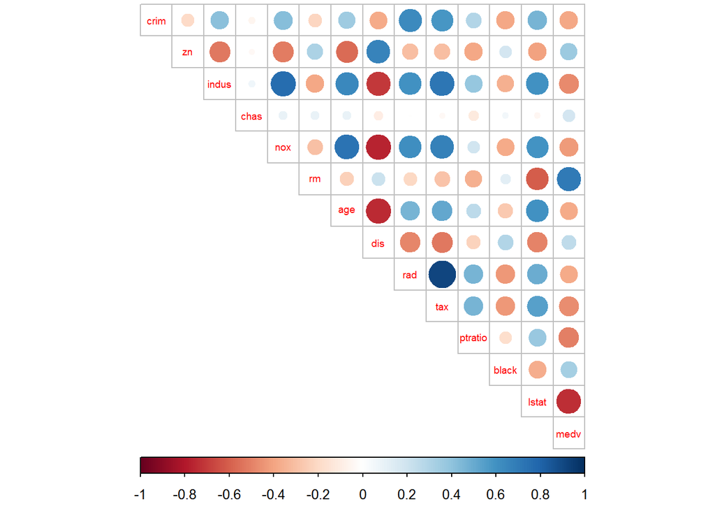

```r
corrplot(cor_matrix, method="circle", type="upper", cl.pos="b", tl.pos="d", tl.cex=0.6)
```

As could be assumed from the scatterplots many of these variables are quite strongly correlated. So for example there is a correlation of .63 between the variables *crim*, which is the crime rate, and *rad*, which is the index of acessibility to radial highways. Highway robbery? Go figure.

There’s a few rather obvious relationships, for example the level of industry *(indus)* is positively correlated with the level of air pollution *(nox)*. To read more about the dangers of nitrogen oxide, see [Wikipedia](https://en.wikipedia.org/wiki/NOx).

Now we’ll standardize the dataset. If I remember to do so I’ll look up an easy explanation for why this needs to be done and *insert it here*. If it’s still missing at the time of assessment, assume I know but forgot to update my diary…

To scale the whole dataset at once, we’ll do this:

```r
myboston_scaled <- scale(Boston)
summary(myboston_scaled)
```

```
##       crim                 zn               indus
##  Min.   :-0.419367   Min.   :-0.48724   Min.   :-1.5563
##  1st Qu.:-0.410563   1st Qu.:-0.48724   1st Qu.:-0.8668
##  Median :-0.390280   Median :-0.48724   Median :-0.2109
##  Mean   : 0.000000   Mean   : 0.00000   Mean   : 0.0000
##  3rd Qu.: 0.007389   3rd Qu.: 0.04872   3rd Qu.: 1.0150
##  Max.   : 9.924110   Max.   : 3.80047   Max.   : 2.4202
##       chas              nox                rm               age
##  Min.   :-0.2723   Min.   :-1.4644   Min.   :-3.8764   Min.   :-2.3331
##  1st Qu.:-0.2723   1st Qu.:-0.9121   1st Qu.:-0.5681   1st Qu.:-0.8366
##  Median :-0.2723   Median :-0.1441   Median :-0.1084   Median : 0.3171
##  Mean   : 0.0000   Mean   : 0.0000   Mean   : 0.0000   Mean   : 0.0000
##  3rd Qu.:-0.2723   3rd Qu.: 0.5981   3rd Qu.: 0.4823   3rd Qu.: 0.9059
##  Max.   : 3.6648   Max.   : 2.7296   Max.   : 3.5515   Max.   : 1.1164
##       dis               rad               tax             ptratio
##  Min.   :-1.2658   Min.   :-0.9819   Min.   :-1.3127   Min.   :-2.7047
##  1st Qu.:-0.8049   1st Qu.:-0.6373   1st Qu.:-0.7668   1st Qu.:-0.4876
##  Median :-0.2790   Median :-0.5225   Median :-0.4642   Median : 0.2746
##  Mean   : 0.0000   Mean   : 0.0000   Mean   : 0.0000   Mean   : 0.0000
##  3rd Qu.: 0.6617   3rd Qu.: 1.6596   3rd Qu.: 1.5294   3rd Qu.: 0.8058
##  Max.   : 3.9566   Max.   : 1.6596   Max.   : 1.7964   Max.   : 1.6372
##      black             lstat              medv
##  Min.   :-3.9033   Min.   :-1.5296   Min.   :-1.9063
##  1st Qu.: 0.2049   1st Qu.:-0.7986   1st Qu.:-0.5989
##  Median : 0.3808   Median :-0.1811   Median :-0.1449
##  Mean   : 0.0000   Mean   : 0.0000   Mean   : 0.0000
##  3rd Qu.: 0.4332   3rd Qu.: 0.6024   3rd Qu.: 0.2683
##  Max.   : 0.4406   Max.   : 3.5453   Max.   : 2.9865
```

```r
myboston_scaled <- as.data.frame(myboston_scaled)
```

That was easy. Now the variables all have a mean of zero and a standard deviation of one.

Now we’re to create a categorical crime rate variable using quantiles as break points. This will allow us to (arbitrarily) define crime rates as low, moderate or high.

```r
cutoffs <- quantile(myboston_scaled$crim)
labels <- c("low", "mod_low", "mod_high", "high")
crim_cat <- cut(myboston_scaled$crim, breaks=cutoffs, include.lowest = TRUE, label = labels)
table(crim_cat)
```

```
## crim_cat
##      low  mod_low mod_high     high
##      127      126      126      127
```

So there we have them tabled, obiously (approximately) the same amount of observations per quantile. Oh, now we have to get rid of the old, continuous *crim*-variable and add the new one:

```r
myboston_scaled <- dplyr::select(myboston_scaled, -crim)
myboston_scaled <- data.frame(myboston_scaled, crim_cat)
str(myboston_scaled)
```

```
## 'data.frame':    506 obs. of  14 variables:
##  $ zn      : num  0.285 -0.487 -0.487 -0.487 -0.487 ...
##  $ indus   : num  -1.287 -0.593 -0.593 -1.306 -1.306 ...
##  $ chas    : num  -0.272 -0.272 -0.272 -0.272 -0.272 ...
##  $ nox     : num  -0.144 -0.74 -0.74 -0.834 -0.834 ...
##  $ rm      : num  0.413 0.194 1.281 1.015 1.227 ...
##  $ age     : num  -0.12 0.367 -0.266 -0.809 -0.511 ...
##  $ dis     : num  0.14 0.557 0.557 1.077 1.077 ...
##  $ rad     : num  -0.982 -0.867 -0.867 -0.752 -0.752 ...
##  $ tax     : num  -0.666 -0.986 -0.986 -1.105 -1.105 ...
##  $ ptratio : num  -1.458 -0.303 -0.303 0.113 0.113 ...
##  $ black   : num  0.441 0.441 0.396 0.416 0.441 ...
##  $ lstat   : num  -1.074 -0.492 -1.208 -1.36 -1.025 ...
##  $ medv    : num  0.16 -0.101 1.323 1.182 1.486 ...
##  $ crim_cat: Factor w/ 4 levels "low","mod_low",..: 1 1 1 1 1 1 2 2 2 2 ...
```

Looks good. Now this dataset needs to be divided into a **training** set and a **testing** set. To do that we’ll use the function *nrow()* to get the number of rows and then randomly select 80% of those for our training set:

```r
n <- nrow(myboston_scaled)
eighty_perc <- sample(n, size = n * 0.8)
train <- myboston_scaled[eighty_perc,]
test <- myboston_scaled[-eighty_perc,]
```

Now it’s time for some LDA. First we’ll compute the LDA fit using all the variables in the dataset:

```r
lda.fit <- lda(crim_cat ~ ., data = train)
lda.fit
```

```
## Call:
## lda(crim_cat ~ ., data = train)
##
## Prior probabilities of groups:
##       low   mod_low  mod_high      high
## 0.2623762 0.2351485 0.2574257 0.2450495
##
## Group means:
##                   zn      indus        chas        nox          rm
## low       1.01325734 -0.9559695 -0.08661679 -0.8797237  0.50173269
## mod_low  -0.07787637 -0.3134010  0.01777305 -0.5702139 -0.08348137
## mod_high -0.41962624  0.2549978  0.18195173  0.4063232  0.04772026
## high     -0.48724019  1.0171737 -0.11325431  1.0192034 -0.39348993
##                 age        dis        rad        tax    ptratio      black
## low      -0.8958905  0.9130034 -0.6817529 -0.7507522 -0.4845063  0.3740061
## mod_low  -0.3354406  0.3671398 -0.5478716 -0.4775790 -0.1029596  0.3317725
## mod_high  0.3741476 -0.3613592 -0.3888647 -0.2609368 -0.1464573  0.1065115
## high      0.8062779 -0.8376973  1.6375616  1.5136504  0.7801170 -0.8496710
##                lstat        medv
## low      -0.79169391  0.56941891
## mod_low  -0.18738333  0.05423149
## mod_high -0.01160485  0.13704998
## high      0.95386144 -0.70350188
##
## Coefficients of linear discriminants:
##                 LD1          LD2         LD3
## zn       0.07417522  0.683980033 -0.88568002
## indus    0.00489095 -0.387947163  0.28737574
## chas    -0.07732112 -0.023715356  0.12511909
## nox      0.33989135 -0.620936824 -1.51307777
## rm      -0.06163592  0.005000266 -0.15475388
## age      0.28300268 -0.254070287 -0.08186381
## dis     -0.07531562 -0.221143254  0.12664420
## rad      2.86835466  1.001949037 -0.04468356
## tax      0.11611220 -0.075161385  0.59434520
## ptratio  0.12923285 -0.075430870 -0.38569571
## black   -0.14233650  0.002868545  0.10755120
## lstat    0.24640581 -0.123681536  0.32743170
## medv     0.19479789 -0.420760584 -0.26888546
##
## Proportion of trace:
##    LD1    LD2    LD3
## 0.9434 0.0432 0.0135
```

Now, I’m a bit slow when it comes to understanding statistics, so i had to listen to this weeks presentation many times, read the blog posts and then dig around the internet for quite some time before being able to give a satisfactory explanation of this output. To start with, the *prior probabilities* should be the number of observations in each class divided by the number of observations in the whole datast. The *group means* show the means for each variable in each class, and in this dataset pretty much every variable has quite different means for different classes of the target variable.

Next i our output we have our *coefficients of linear discriminants*. This is the output I had to shop around for a proper explanation. I liked [this one](https://rstudio-pubs-static.s3.amazonaws.com/35817_2552e05f1d4e4db8ba87b334101a43da.html).

Then last, the *proportion of trace* tells us that our first discriminant function explains 94,4% of the between group variance while LD2 and LD3 add a pitiful 5,6% combined.

Then we’ll draw a biplot:

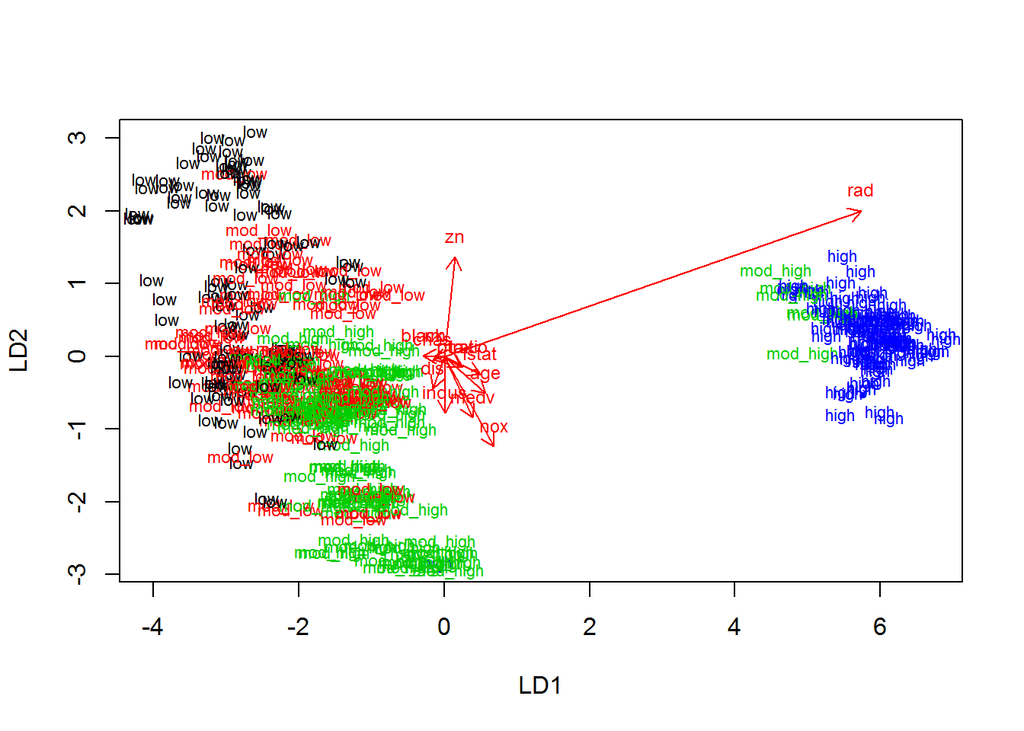

```r
lda.arrows <- function(x, myscale = 0.5, arrow_heads = 0.1, color = "red", tex = 0.75, choices = c(1,2)){
  heads <- coef(x)
  arrows(x0 = 0, y0 = 0,
         x1 = myscale * heads[,choices[1]],
         y1 = myscale * heads[,choices[2]], col=color, length = arrow_heads)
  text(myscale * heads[,choices], labels = row.names(heads),
       cex = tex, col=color, pos=3)
}
classes <- as.numeric(train$crim_cat)
plot(lda.fit, dimen = 2, col = classes, pch = classes)
lda.arrows(lda.fit, myscale = 2)
```

As we can see, the length of the arrows correspond with the size of the discriminant coefficients in the lda output above, i.e. *rad* has the largest absolute value (for LD1) and the longest arrow, *zn* and *nox* have high absolute values for LD2 and LD3. What this plot also shows is that while LD1 seems to discriminate very well between high crime and the rest, LD2 helps to discriminate the other 3 groups. How to illustrate LD3 is beyond me, so onwards with some predictions.